```python
#!pip install librosa
#!pip install mutagen
```

# Extract Features from Audio

MFCC

```python
import librosa
import librosa.display
import librosa.feature
import IPython.display as ipd
import matplotlib as plt
import os
from mutagen.flac import FLAC
```

```python
import librosa
import numpy as np

# Function to extract MFCC features with slicing for long files
def extract_mfcc_sliced(audio_path, target_duration=2, sr=22050, n_mfcc=13):
    # Load the audio file
    y, sr = librosa.load(audio_path, sr=sr)
    target_length = sr * target_duration
    num_chunks = len(y) // target_length

    data= {
        "mfccs_list": [],
        "labels": []
    }
    # Slice the audio into chunks
    for i in range(num_chunks):
        start_sample = i * target_length
        end_sample = start_sample + target_length
        chunk = y[start_sample:end_sample]

        # Extract MFCCs for the chunk
        mfccs = librosa.feature.mfcc(y=chunk, sr=sr, n_mfcc=n_mfcc)
        data["mfccs_list"].append(mfccs)
        if audio_path.split("\\")[1] == "male":
            data["labels"].append(0)
        else:
            data["labels"].append(1)


    # processs the remaining
    remainder = len(y) % target_length
    if remainder > 0:
        chunk = np.pad(y[-remainder:], (0, target_length - remainder), 'constant')
        mfccs = librosa.feature.mfcc(y=chunk, sr=sr, n_mfcc=n_mfcc)
        data["mfccs_list"].append(mfccs)
        if audio_path.split("\\")[1] == "male":
            data["labels"].append(0)
        else:
            data["labels"].append(1)

    return data
```

# Calling the MFCC extractor function

```python
data={
    "mfccs_list": [],
    "labels": []
}
dataset_path = ".\\"
for i,(dirpath,dirnames, filenames) in enumerate(os.walk(dataset_path)):
    dirpath_components = dirpath.split("/")
    if filenames != []:
        for j,file in enumerate(filenames):
            if file[-4:] == "flac":

                mfcc_chunk = extract_mfcc_sliced(dirpath + "\\"+ file, target_duration=2)
                data["mfccs_list"].extend(mfcc_chunk["mfccs_list"])  # Add all segments as separate data points
                data["labels"].extend(mfcc_chunk["labels"])
```

# Creating the csv file by flattening the 13 MFCC features

```python
#reshaping mfccs to 1d array and creating a
import numpy as np
import csv
# Flatten each MFCC (13x87) to a 1D array (1131)
flattened_mfccs = data["mfccs_list"].reshape(data["mfccs_list"].shape[0], -1)

# Combine MFCCs and labels (adding the labels as the last column)
combined_data = np.column_stack((flattened_mfccs, data["labels"]))
csv_file_path = 'mfccs_and_labels.csv'

# Save
with open(csv_file_path, mode='w', newline='') as file:
    writer = csv.writer(file)

    header = [f'mfcc_{i}' for i in range(flattened_mfccs.shape[1])] + ['label']
    writer.writerow(header)
    writer.writerows(combined_data)

print(f"Data successfully saved to {csv_file_path}")
```

```
Data successfully saved to mfccs_and_labels.csv
```

# KNN implementation with different PCA explained variance and different values for number of neighbours

```
Best Parameters: {'knn__n_neighbors': 3, 'pca__n_components': 0.8}
Best Cross-Validation Accuracy: 0.8463
```

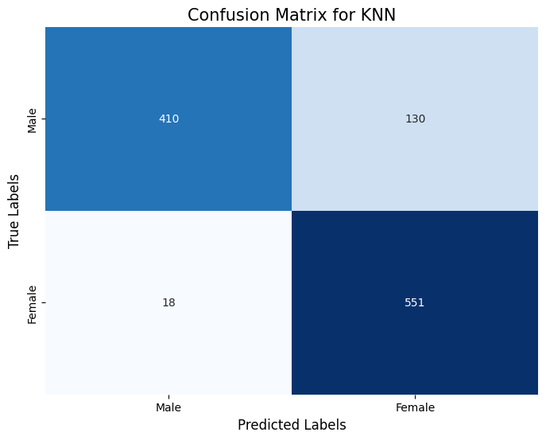

[output not shown]

```python
import pandas as pd
import numpy as np
import matplotlib.pyplot as plt
import seaborn as sns
from sklearn.model_selection import KFold, GridSearchCV, train_test_split
from sklearn.neighbors import KNeighborsClassifier
from sklearn.decomposition import PCA
from sklearn.preprocessing import StandardScaler
from sklearn.pipeline import Pipeline
from sklearn.metrics import confusion_matrix, precision_score, recall_score, f1_score, accuracy_score

data = pd.read_csv('mfccs_and_labels.csv', header=0)

# Separate features (MFCCs) and labels
X = data.drop(columns=['label']).astype(np.float32).to_numpy()  # Convert features to float32
y = data['label'].astype(np.int32).to_numpy()  # Convert labels to integers

# Split into training and test sets
X_train, X_test, y_train, y_test = train_test_split(X, y, test_size=0.2, random_state=42)

# Create a pipeline for PCA, StandardScaler, and KNN
pipeline = Pipeline([
    ('scaler', StandardScaler()),
    ('pca', PCA()),
    ('knn', KNeighborsClassifier())
])

# GridSearchCV to test different PCA components and K values
param_grid = {
    'pca__n_components': [0.8, 0.85, 0.9, 0.95],  # Test different percentages of explained variance
    'knn__n_neighbors': [3, 5, 7, 9]  # Test different K values
}

kf = KFold(n_splits=10, shuffle=True, random_state=42)
grid = GridSearchCV(pipeline, param_grid, cv=kf, scoring='accuracy')

# Fit the model
grid.fit(X_train, y_train)
print(f"Best Parameters: {grid.best_params_}")
print(f"Best Cross-Validation Accuracy: {grid.best_score_:.4f}")

# Predict on the test set
y_pred = grid.best_estimator_.predict(X_test)


conf_matrix = confusion_matrix(y_test, y_pred)
precision = precision_score(y_test, y_pred)
recall = recall_score(y_test, y_pred)
f1 = f1_score(y_test, y_pred)
accuracy = accuracy_score(y_test, y_pred)

plt.figure(figsize=(8, 6))
sns.heatmap(conf_matrix, annot=True, fmt='g', cmap='Blues', cbar=False,
            xticklabels=['Male', 'Female'], yticklabels=['Male', 'Female'])
plt.title('Confusion Matrix for KNN', fontsize=15)
plt.xlabel('Predicted Labels', fontsize=12)
plt.ylabel('True Labels', fontsize=12)
plt.show()


print(f'Accuracy: {accuracy:.2f}')
print(f'Precision: {precision:.2f}')
print(f'Recall: {recall:.2f}')
print(f'F1 Score: {f1:.2f}')
```

### For a basic model like KNN I think the performance was really good. Standartization and doing PCA increased the scores very much. Without them the accuracy was ~0.65 Since the knn did a good job I guess the distribution is non-linear. To test that I will implement SVM with linear kernel function

# SVM algorithm with linear kernel function.

```python
from sklearn.decomposition import PCA
from sklearn.preprocessing import StandardScaler
from sklearn.svm import SVC
from sklearn.model_selection import cross_val_predict, KFold
from sklearn.metrics import confusion_matrix, classification_report, precision_score, recall_score, f1_score
import numpy as np
import pandas as pd


data = pd.read_csv("mfccs_and_labels.csv",header=0)

X = data.drop(columns=["label"])  # Assuming the label column is named "label"
y = data["label"]


scaler = StandardScaler()
X_scaled = scaler.fit_transform(X)

# Try different n_components for PCA
n_components_list = [0.8, 0.85, 0.9, 0.95]
kf = KFold(n_splits=10, shuffle=True, random_state=42)  # 10-fold cv

for n_components in n_components_list:

    pca = PCA(n_components=n_components)
    X_pca = pca.fit_transform(X_scaled)
    svm = SVC(kernel="linear", random_state=42)
    y_pred = cross_val_predict(svm, X_pca, y, cv=kf)


    cm = confusion_matrix(y, y_pred)
    print(f"\nPCA {n_components * 100}% components:")
    print("Confusion Matrix:")
    print(cm)

    if cm.shape == (2, 2):
        TN, FP, FN, TP = cm.ravel()


    precision = precision_score(y, y_pred, average='macro')
    recall = recall_score(y, y_pred, average='macro')
    f1 = f1_score(y, y_pred, average='macro')

    print(f"Precision: {precision:.4f}")
    print(f"Recall: {recall:.4f}")
    print(f"F1 Score: {f1:.4f}")

    print("\nClassification Report:")
    print(classification_report(y, y_pred))

    scores = cross_val_predict(svm, X_pca, y, cv=kf)
    mean_accuracy = np.mean(scores)
    print(f"Mean Accuracy: {mean_accuracy:.4f}")
```

```
PCA 80.0% components:
Confusion Matrix:
[[2100  661]
 [ 485 2299]]
Precision: 0.7945
Recall: 0.7932
F1 Score: 0.7931

Classification Report:
              precision    recall  f1-score   support

         0.0       0.81      0.76      0.79      2761
         1.0       0.78      0.83      0.80      2784

    accuracy                           0.79      5545
   macro avg       0.79      0.79      0.79      5545
weighted avg       0.79      0.79      0.79      5545

Mean Accuracy: 0.5338

PCA 85.0% components:
Confusion Matrix:
[[2093  668]
 [ 495 2289]]
Precision: 0.7914
Recall: 0.7901
F1 Score: 0.7900

Classification Report:
              precision    recall  f1-score   support

         0.0       0.81      0.76      0.78      2761
         1.0       0.77      0.82      0.80      2784

    accuracy                           0.79      5545
   macro avg       0.79      0.79      0.79      5545
weighted avg       0.79      0.79      0.79      5545

Mean Accuracy: 0.5333

```

[output cut: 24 more lines]

```
Precision: 0.7799
Recall: 0.7793
F1 Score: 0.7793

Classification Report:
              precision    recall  f1-score   support

         0.0       0.79      0.76      0.77      2761
         1.0       0.77      0.80      0.78      2784

    accuracy                           0.78      5545
   macro avg       0.78      0.78      0.78      5545
weighted avg       0.78      0.78      0.78      5545

Mean Accuracy: 0.5232
```

### SVM with linear function suffered a lot both in time and scores. I tried to add non-linear kernel functions but the process took more than 2 hours and it was still running. To check the non-linear distribution I will do PCA with 2 features and look at the clustering of the 2 groups

```
Best Parameters: {'knn__n_neighbors': 3, 'pca__n_components': 0.8}
Best Cross-Validation Accuracy: 0.8463
```

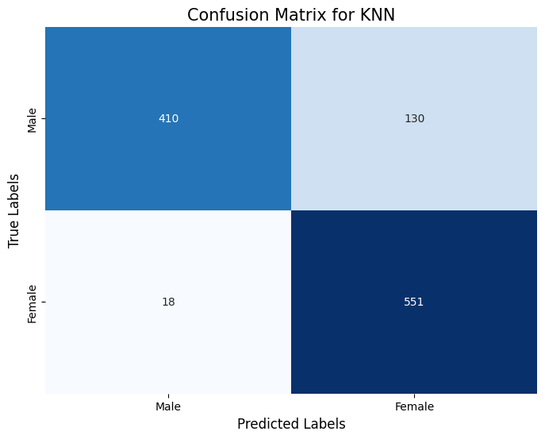

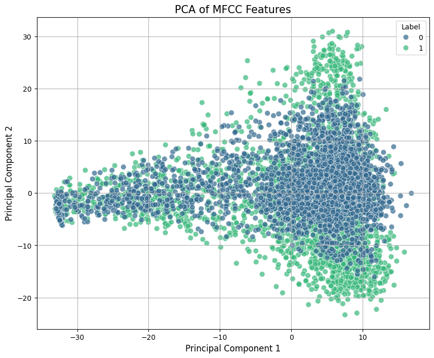

```
Accuracy: 0.87
Precision: 0.88
Recall: 0.87
F1 Score: 0.86
```

```python
import pandas as pd
import numpy as np
import matplotlib.pyplot as plt
import seaborn as sns
from sklearn.model_selection import KFold, GridSearchCV, train_test_split
from sklearn.neighbors import KNeighborsClassifier
from sklearn.decomposition import PCA
from sklearn.preprocessing import StandardScaler
from sklearn.pipeline import Pipeline
from sklearn.metrics import confusion_matrix, precision_score, recall_score, f1_score, accuracy_score

data = pd.read_csv('mfccs_and_labels.csv', header=0)

# Separate features (MFCCs) and labels
X = data.drop(columns=['label']).astype(np.float32).to_numpy()  # Convert features to float32
y = data['label'].astype(np.int32).to_numpy()  # Convert labels to integers

# Split into training and test sets
X_train, X_test, y_train, y_test = train_test_split(X, y, test_size=0.2, random_state=42)

# Create a pipeline for PCA, StandardScaler, and KNN
pipeline = Pipeline([
    ('scaler', StandardScaler()),
    ('pca', PCA()),
    ('knn', KNeighborsClassifier())
])

# GridSearchCV to test different PCA components and K values
param_grid = {
    'pca__n_components': [0.8, 0.85, 0.9, 0.95],  # Test different percentages of explained variance
    'knn__n_neighbors': [3, 5, 7, 9]  # Test different K values
}

kf = KFold(n_splits=10, shuffle=True, random_state=42)
grid = GridSearchCV(pipeline, param_grid, cv=kf, scoring='accuracy')

# Fit the model
grid.fit(X_train, y_train)
print(f"Best Parameters: {grid.best_params_}")
print(f"Best Cross-Validation Accuracy: {grid.best_score_:.4f}")

# Predict on the test set
y_pred = grid.best_estimator_.predict(X_test)

# Confusion Matrix
conf_matrix = confusion_matrix(y_test, y_pred)
precision = precision_score(y_test, y_pred, average='weighted')
recall = recall_score(y_test, y_pred, average='weighted')
f1 = f1_score(y_test, y_pred, average='weighted')
accuracy = accuracy_score(y_test, y_pred)

# Plot Confusion Matrix
plt.figure(figsize=(8, 6))
sns.heatmap(conf_matrix, annot=True, fmt='g', cmap='Blues', cbar=False,
            xticklabels=['Male', 'Female'], yticklabels=['Male', 'Female'])
plt.title('Confusion Matrix for KNN', fontsize=15)
plt.xlabel('Predicted Labels', fontsize=12)
plt.ylabel('True Labels', fontsize=12)
plt.show()

# PCA Visualization
scaler = StandardScaler()
X_scaled = scaler.fit_transform(X)  # Standardize the entire dataset

pca = PCA(n_components=2)
X_pca = pca.fit_transform(X_scaled)

# Create a DataFrame for PCA results
pca_df = pd.DataFrame(data=X_pca, columns=['PC1', 'PC2'])
pca_df['label'] = y

# Plotting PCA results with clusters
plt.figure(figsize=(10, 8))
sns.scatterplot(data=pca_df, x='PC1', y='PC2', hue='label', palette='viridis', s=60, alpha=0.7)
plt.title('PCA of MFCC Features', fontsize=15)
plt.xlabel('Principal Component 1', fontsize=12)
plt.ylabel('Principal Component 2', fontsize=12)
plt.legend(title='Label')
plt.grid(True)
plt.show()

# Print metrics
print(f'Accuracy: {accuracy:.2f}')
print(f'Precision: {precision:.2f}')
print(f'Recall: {recall:.2f}')
print(f'F1 Score: {f1:.2f}')
```

### 2 features that explains the variance in data plotted and the distribution seems non-linear. Thats why knn did a better job

# Neural network

```
139/139 ━━━━━━━━━━━━━━━━━━━━ 1s 2ms/step - accuracy: 0.7361 - loss: 0.5413 - val_accuracy: 0.8747 - val_loss: 0.2669
139/139 ━━━━━━━━━━━━━━━━━━━━ 0s 1ms/step - accuracy: 0.8746 - loss: 0.2667 - val_accuracy: 0.9017 - val_loss: 0.2197
139/139 ━━━━━━━━━━━━━━━━━━━━ 0s 1ms/step - accuracy: 0.9010 - loss: 0.2133 - val_accuracy: 0.9053 - val_loss: 0.1958
139/139 ━━━━━━━━━━━━━━━━━━━━ 0s 1ms/step - accuracy: 0.9148 - loss: 0.1804 - val_accuracy: 0.9062 - val_loss: 0.2014
139/139 ━━━━━━━━━━━━━━━━━━━━ 0s 1ms/step - accuracy: 0.9292 - loss: 0.1555 - val_accuracy: 0.8909 - val_loss: 0.2082
139/139 ━━━━━━━━━━━━━━━━━━━━ 0s 1ms/step - accuracy: 0.9357 - loss: 0.1350 - val_accuracy: 0.8900 - val_loss: 0.2346
139/139 ━━━━━━━━━━━━━━━━━━━━ 0s 1ms/step - accuracy: 0.9409 - loss: 0.1243 - val_accuracy: 0.9080 - val_loss: 0.2108
139/139 ━━━━━━━━━━━━━━━━━━━━ 0s 1ms/step - accuracy: 0.9450 - loss: 0.1238 - val_accuracy: 0.9053 - val_loss: 0.2129
139/139 ━━━━━━━━━━━━━━━━━━━━ 0s 1ms/step - accuracy: 0.9543 - loss: 0.0999 - val_accuracy: 0.9107 - val_loss: 0.2125
139/139 ━━━━━━━━━━━━━━━━━━━━ 0s 1ms/step - accuracy: 0.9554 - loss: 0.0935 - val_accuracy: 0.9080 - val_loss: 0.2311
139/139 ━━━━━━━━━━━━━━━━━━━━ 0s 1ms/step - accuracy: 0.9531 - loss: 0.1049 - val_accuracy: 0.9098 - val_loss: 0.2239
139/139 ━━━━━━━━━━━━━━━━━━━━ 0s 1ms/step - accuracy: 0.9554 - loss: 0.1044 - val_accuracy: 0.9116 - val_loss: 0.2104
139/139 ━━━━━━━━━━━━━━━━━━━━ 0s 1ms/step - accuracy: 0.9635 - loss: 0.0863 - val_accuracy: 0.9188 - val_loss: 0.2319
139/139 ━━━━━━━━━━━━━━━━━━━━ 0s 1ms/step - accuracy: 0.9647 - loss: 0.0754 - val_accuracy: 0.9143 - val_loss: 0.2402
139/139 ━━━━━━━━━━━━━━━━━━━━ 0s 1ms/step - accuracy: 0.9702 - loss: 0.0703 - val_accuracy: 0.9125 - val_loss: 0.2560
139/139 ━━━━━━━━━━━━━━━━━━━━ 0s 1ms/step - accuracy: 0.9613 - loss: 0.0758 - val_accuracy: 0.9080 - val_loss: 0.2583
139/139 ━━━━━━━━━━━━━━━━━━━━ 0s 1ms/step - accuracy: 0.9674 - loss: 0.0660 - val_accuracy: 0.9098 - val_loss: 0.2706
139/139 ━━━━━━━━━━━━━━━━━━━━ 0s 1ms/step - accuracy: 0.9636 - loss: 0.0794 - val_accuracy: 0.9098 - val_loss: 0.2720
139/139 ━━━━━━━━━━━━━━━━━━━━ 0s 1ms/step - accuracy: 0.9663 - loss: 0.0790 - val_accuracy: 0.9116 - val_loss: 0.2619
139/139 ━━━━━━━━━━━━━━━━━━━━ 0s 1ms/step - accuracy: 0.9651 - loss: 0.0821 - val_accuracy: 0.9125 - val_loss: 0.2694
35/35 ━━━━━━━━━━━━━━━━━━━━ 0s 550us/step - accuracy: 0.9123 - loss: 0.2637
Test Accuracy: 0.9125
35/35 ━━━━━━━━━━━━━━━━━━━━ 0s 883us/step
Confusion Matrix:
[[502  38]
 [ 59 510]]
Precision: 0.9307
Recall: 0.8963
F1 Score: 0.9132

Classification Report:
              precision    recall  f1-score   support

         0.0       0.89      0.93      0.91       540
         1.0       0.93      0.90      0.91       569

    accuracy                           0.91      1109
   macro avg       0.91      0.91      0.91      1109
weighted avg       0.91      0.91      0.91      1109
```

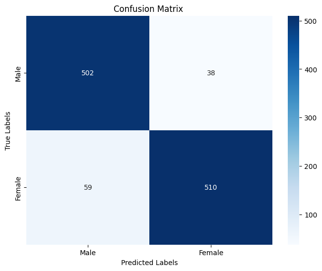

```
Precision: 0.93
Recall: 0.90
F1 Score: 0.91
Accuracy: 0.91
```

```python
import pandas as pd
import numpy as np
from sklearn.model_selection import train_test_split
from sklearn.preprocessing import StandardScaler
from sklearn.metrics import confusion_matrix, classification_report, precision_score, recall_score, f1_score
from keras.models import Sequential
from keras.layers import Dense, Dropout


data = pd.read_csv("mfccs_and_labels.csv")


X = data.drop(columns=["label"])
y = data["label"]

##REMOVED
#scaler = StandardScaler()
#X_scaled = scaler.fit_transform(X)


X_train, X_test, y_train, y_test = train_test_split(X_scaled, y, test_size=0.2, random_state=42)

# Build the nn
model = Sequential()


model.add(Dense(128, input_dim=X_train.shape[1], activation='relu'))
model.add(Dropout(0.3))  #for regularization
model.add(Dense(64, activation='relu'))
model.add(Dropout(0.3))
model.add(Dense(1, activation='sigmoid')) #output layer
model.compile(optimizer='adam', loss='binary_crossentropy', metrics=['accuracy'])


model.fit(X_train, y_train, epochs=20, batch_size=32, validation_data=(X_test, y_test))

# Evaluate the model on the test set
test_loss, test_acc = model.evaluate(X_test, y_test)
print(f"Test Accuracy: {test_acc:.4f}")
y_pred_prob = model.predict(X_test)
y_pred = (y_pred_prob > 0.5).astype(int)  # Binarize


cm = confusion_matrix(y_test, y_pred)
print("Confusion Matrix:")
print(cm)


if cm.shape == (2, 2):
    TN, FP, FN, TP = cm.ravel()


precision = precision_score(y_test, y_pred)
recall = recall_score(y_test, y_pred)
f1 = f1_score(y_test, y_pred)

print(f"Precision: {precision:.4f}")
print(f"Recall: {recall:.4f}")
print(f"F1 Score: {f1:.4f}")


print("\nClassification Report:")
print(classification_report(y_test, y_pred))



conf_matrix = confusion_matrix(y_test, y_pred)
precision = precision_score(y_test, y_pred)
recall = recall_score(y_test, y_pred)
f1 = f1_score(y_test, y_pred)
accuracy = accuracy_score(y_test, y_pred)


plt.figure(figsize=(8, 6))
sns.heatmap(conf_matrix, annot=True, fmt='g', cmap='Blues', xticklabels=['Male', 'Female'], yticklabels=['Male', 'Female'])
plt.title('Confusion Matrix ')
plt.xlabel('Predicted Labels')
plt.ylabel('True Labels')
plt.show()


print(f'Precision: {precision:.2f}')
print(f'Recall: {recall:.2f}')
print(f'F1 Score: {f1:.2f}')
print(f'Accuracy: {accuracy:.2f}')
```

### As expected neural network did a better job than both knn and svm. Since I saved the extracted features as 1D array I will first build a 1D CNN then I will reshape my data and build 2D CNN. In the literature they say 2D CNN gives much better results when using MFCC features due to two dimentional structure of the MFCC's. Also MFCC is created by considering time so it suits better to 2D CNNs.

# 1D CNN

```
(5545, 1132)
```

```
139/139 ━━━━━━━━━━━━━━━━━━━━ 4s 21ms/step - accuracy: 0.6525 - loss: 8.8325 - val_accuracy: 0.8765 - val_loss: 0.2733
139/139 ━━━━━━━━━━━━━━━━━━━━ 3s 19ms/step - accuracy: 0.8568 - loss: 0.3099 - val_accuracy: 0.8855 - val_loss: 0.2524
139/139 ━━━━━━━━━━━━━━━━━━━━ 3s 20ms/step - accuracy: 0.9308 - loss: 0.1617 - val_accuracy: 0.8828 - val_loss: 0.2700
139/139 ━━━━━━━━━━━━━━━━━━━━ 3s 19ms/step - accuracy: 0.9555 - loss: 0.1172 - val_accuracy: 0.8629 - val_loss: 0.3178
139/139 ━━━━━━━━━━━━━━━━━━━━ 3s 20ms/step - accuracy: 0.9576 - loss: 0.1011 - val_accuracy: 0.8593 - val_loss: 0.4126
139/139 ━━━━━━━━━━━━━━━━━━━━ 3s 19ms/step - accuracy: 0.9672 - loss: 0.0727 - val_accuracy: 0.8702 - val_loss: 0.3847
139/139 ━━━━━━━━━━━━━━━━━━━━ 3s 19ms/step - accuracy: 0.9800 - loss: 0.0581 - val_accuracy: 0.8656 - val_loss: 0.4490
139/139 ━━━━━━━━━━━━━━━━━━━━ 3s 19ms/step - accuracy: 0.9848 - loss: 0.0433 - val_accuracy: 0.8720 - val_loss: 0.4067
139/139 ━━━━━━━━━━━━━━━━━━━━ 3s 19ms/step - accuracy: 0.9895 - loss: 0.0313 - val_accuracy: 0.8711 - val_loss: 0.4389
139/139 ━━━━━━━━━━━━━━━━━━━━ 3s 19ms/step - accuracy: 0.9874 - loss: 0.0280 - val_accuracy: 0.8738 - val_loss: 0.5318
35/35 ━━━━━━━━━━━━━━━━━━━━ 0s 5ms/step - accuracy: 0.8764 - loss: 0.5098
Test accuracy: 0.8738
35/35 ━━━━━━━━━━━━━━━━━━━━ 0s 6ms/step
Confusion Matrix:
[[486  54]
 [ 86 483]]
Precision: 0.8994
Recall: 0.8489
F1 Score: 0.8734

Classification Report:
              precision    recall  f1-score   support

           0       0.85      0.90      0.87       540
           1       0.90      0.85      0.87       569

    accuracy                           0.87      1109
   macro avg       0.87      0.87      0.87      1109
weighted avg       0.88      0.87      0.87      1109
```

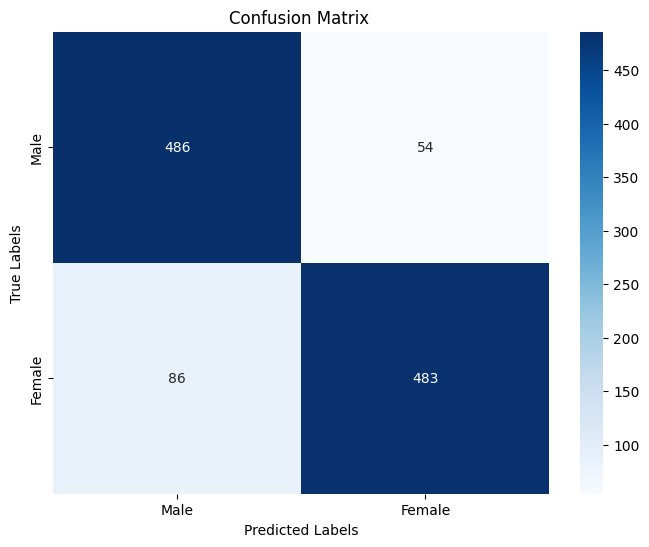

```
Precision: 0.90
Recall: 0.85
F1 Score: 0.87
Accuracy: 0.87
```

```python
import pandas as pd
import numpy as np
from sklearn.model_selection import train_test_split
from sklearn.metrics import confusion_matrix, classification_report, precision_score, recall_score, f1_score
from tensorflow.keras import layers, models


data = pd.read_csv('mfccs_and_labels.csv', header=0)
print(data.shape)
X = data.drop(columns=['label']).astype(np.float32).to_numpy()
y = data['label'].astype(np.int32).to_numpy()
# Reshape the MFCCs for 1D CNN
X_reshaped = X.reshape(X.shape[0], X.shape[1], 1)
X_train, X_test, y_train, y_test = train_test_split(X_reshaped, y, test_size=0.2, random_state=42)
model = models.Sequential()


model.add(layers.Conv1D(32, kernel_size=3, activation='relu', input_shape=(X_reshaped.shape[1], 1)))
model.add(layers.MaxPooling1D(pool_size=2))
model.add(layers.Conv1D(64, kernel_size=3, activation='relu'))
model.add(layers.MaxPooling1D(pool_size=2))
model.add(layers.Conv1D(128, kernel_size=3, activation='relu'))
model.add(layers.Flatten())
model.add(layers.Dense(128, activation='relu'))
model.add(layers.Dense(1, activation='sigmoid'))  # Binary output
model.compile(optimizer='adam', loss='binary_crossentropy', metrics=['accuracy'])
model.fit(X_train, y_train, epochs=10, batch_size=32, validation_data=(X_test, y_test))


test_loss, test_acc = model.evaluate(X_test, y_test)
print(f"Test accuracy: {test_acc:.4f}")
y_pred_prob = model.predict(X_test)
y_pred = (y_pred_prob > 0.5).astype(int)

cm = confusion_matrix(y_test, y_pred)
print("Confusion Matrix:")
print(cm)

if cm.shape == (2, 2):
    TN, FP, FN, TP = cm.ravel()


precision = precision_score(y_test, y_pred)
recall = recall_score(y_test, y_pred)
f1 = f1_score(y_test, y_pred)

print(f"Precision: {precision:.4f}")
print(f"Recall: {recall:.4f}")
print(f"F1 Score: {f1:.4f}")


print("\nClassification Report:")
print(classification_report(y_test, y_pred))

conf_matrix = confusion_matrix(y_test, y_pred)
precision = precision_score(y_test, y_pred)
recall = recall_score(y_test, y_pred)
f1 = f1_score(y_test, y_pred)
accuracy = accuracy_score(y_test, y_pred)


plt.figure(figsize=(8, 6))
sns.heatmap(conf_matrix, annot=True, fmt='g', cmap='Blues', xticklabels=['Male', 'Female'], yticklabels=['Male', 'Female'])
plt.title('Confusion Matrix ')
plt.xlabel('Predicted Labels')
plt.ylabel('True Labels')
plt.show()


print(f'Precision: {precision:.2f}')
print(f'Recall: {recall:.2f}')
print(f'F1 Score: {f1:.2f}')
print(f'Accuracy: {accuracy:.2f}')
```

# 2D CNN

```
X_train shape: (4436, 13, 87, 1), y_train shape: (4436,)
X_test shape: (1109, 13, 87, 1), y_test shape: (1109,)
Unique labels in y_train: [0 1]
```

```
139/139 ━━━━━━━━━━━━━━━━━━━━ 2s 8ms/step - accuracy: 0.6286 - loss: 5.3794 - val_accuracy: 0.7782 - val_loss: 0.4534
139/139 ━━━━━━━━━━━━━━━━━━━━ 1s 7ms/step - accuracy: 0.8718 - loss: 0.2709 - val_accuracy: 0.8945 - val_loss: 0.2156
139/139 ━━━━━━━━━━━━━━━━━━━━ 1s 7ms/step - accuracy: 0.8957 - loss: 0.2371 - val_accuracy: 0.9324 - val_loss: 0.1452
139/139 ━━━━━━━━━━━━━━━━━━━━ 1s 7ms/step - accuracy: 0.9375 - loss: 0.1594 - val_accuracy: 0.9351 - val_loss: 0.1478
139/139 ━━━━━━━━━━━━━━━━━━━━ 1s 7ms/step - accuracy: 0.9568 - loss: 0.1003 - val_accuracy: 0.9324 - val_loss: 0.1487
139/139 ━━━━━━━━━━━━━━━━━━━━ 1s 7ms/step - accuracy: 0.9519 - loss: 0.1084 - val_accuracy: 0.9531 - val_loss: 0.1191
139/139 ━━━━━━━━━━━━━━━━━━━━ 1s 7ms/step - accuracy: 0.9615 - loss: 0.0966 - val_accuracy: 0.9558 - val_loss: 0.1086
139/139 ━━━━━━━━━━━━━━━━━━━━ 1s 7ms/step - accuracy: 0.9821 - loss: 0.0466 - val_accuracy: 0.9188 - val_loss: 0.2079
139/139 ━━━━━━━━━━━━━━━━━━━━ 1s 7ms/step - accuracy: 0.9678 - loss: 0.0734 - val_accuracy: 0.9441 - val_loss: 0.1407
139/139 ━━━━━━━━━━━━━━━━━━━━ 1s 7ms/step - accuracy: 0.9817 - loss: 0.0524 - val_accuracy: 0.9585 - val_loss: 0.1173
35/35 ━━━━━━━━━━━━━━━━━━━━ 0s 3ms/step - accuracy: 0.9571 - loss: 0.1097
Test accuracy: 0.9585
35/35 ━━━━━━━━━━━━━━━━━━━━ 0s 3ms/step
Confusion Matrix:
[[519  21]
 [ 25 544]]
Precision: 0.9628
Recall: 0.9561
F1 Score: 0.9594

Classification Report:
              precision    recall  f1-score   support

           0       0.95      0.96      0.96       540
           1       0.96      0.96      0.96       569

    accuracy                           0.96      1109
   macro avg       0.96      0.96      0.96      1109
weighted avg       0.96      0.96      0.96      1109
```

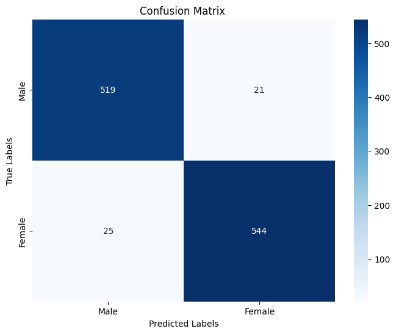

```
Precision: 0.96
Recall: 0.96
F1 Score: 0.96
Accuracy: 0.96
```

```python
import pandas as pd
import numpy as np
from sklearn.model_selection import train_test_split
from sklearn.metrics import confusion_matrix, classification_report, precision_score, recall_score, f1_score
from tensorflow.keras import layers, models


data = pd.read_csv('mfccs_and_labels.csv', header=0)


X = data.drop(columns=['label']).astype(np.float32).to_numpy()
y = data['label'].astype(np.int32).to_numpy()

# Step 3: Reshape the MFCCs from (5545, 1131) to (5545, 13, 87, 1) for 2D CNN
try:
    X_reshaped = X.reshape(X.shape[0], 13, 87, 1)
except ValueError as e:
    print(f"Error in reshaping: {e}")
    print(f"Shape of X: {X.shape}")
    exit()


X_train, X_test, y_train, y_test = train_test_split(X_reshaped, y, test_size=0.2, random_state=42)
y_train = y_train.flatten()
y_test = y_test.flatten()
print(f"X_train shape: {X_train.shape}, y_train shape: {y_train.shape}")
print(f"X_test shape: {X_test.shape}, y_test shape: {y_test.shape}")
print(f"Unique labels in y_train: {np.unique(y_train)}")


model = models.Sequential()
model.add(layers.Conv2D(32, (3, 3), padding='same', activation='relu', input_shape=(13, 87, 1)))
model.add(layers.MaxPooling2D((2, 2)))
model.add(layers.Conv2D(64, (3, 3), padding='same', activation='relu'))
model.add(layers.MaxPooling2D((2, 2)))
model.add(layers.Conv2D(128, (3, 3), padding='same', activation='relu'))
model.add(layers.Flatten())
model.add(layers.Dense(128, activation='relu'))
model.add(layers.Dense(1, activation='sigmoid'))
model.compile(optimizer='adam', loss='binary_crossentropy', metrics=['accuracy'])
model.fit(X_train, y_train, epochs=10, batch_size=32, validation_data=(X_test, y_test))


test_loss, test_acc = model.evaluate(X_test, y_test)
print(f"Test accuracy: {test_acc:.4f}")


y_pred_prob = model.predict(X_test)
y_pred = (y_pred_prob > 0.5).astype(int)


cm = confusion_matrix(y_test, y_pred)
print("Confusion Matrix:")
print(cm)

precision = precision_score(y_test, y_pred)
recall = recall_score(y_test, y_pred)
f1 = f1_score(y_test, y_pred)
print(f"Precision: {precision:.4f}")
print(f"Recall: {recall:.4f}")
print(f"F1 Score: {f1:.4f}")
print("\nClassification Report:")
print(classification_report(y_test, y_pred))

conf_matrix = confusion_matrix(y_test, y_pred)
precision = precision_score(y_test, y_pred)
recall = recall_score(y_test, y_pred)
f1 = f1_score(y_test, y_pred)
accuracy = accuracy_score(y_test, y_pred)

plt.figure(figsize=(8, 6))
sns.heatmap(conf_matrix, annot=True, fmt='g', cmap='Blues', xticklabels=['Male', 'Female'], yticklabels=['Male', 'Female'])
plt.title('Confusion Matrix ')
plt.xlabel('Predicted Labels')
plt.ylabel('True Labels')
plt.show()

print(f'Precision: {precision:.2f}')
print(f'Recall: {recall:.2f}')
print(f'F1 Score: {f1:.2f}')
print(f'Accuracy: {accuracy:.2f}')
```

### As expected 2D CNN performed the best amongst all algorithms. But the performance of the kNN algorithm was surprising a lot. It almost catch the performance of the 1D CNN's results

I played with the wav2vec a little bit to understand it in here

```python
from transformers import Wav2Vec2Model, Wav2Vec2Processor
import torch
import librosa

model_name = "facebook/wav2vec2-base"
pre_processor = Wav2Vec2Processor.from_pretrained(model_name)
model = Wav2Vec2Model.from_pretrained(model_name)
```

```python
audio_file_path = "174-50561-0000.flac"
audio, sr = librosa.load(audio_file_path,sr=16000)
```

```python
inputs = pre_processor(audio,sampling_rate=sr, return_tensors='pt', padding= True)
with torch.no_grad():
    features = model(**inputs).last_hidden_state

np_features = features.squeeze().cpu().numpy()
np_features.shape
```

```
(200, 768)
```

# Creating the dataset for speaker identification

```python
import os
import torch
import torchaudio
import numpy as np
from transformers import Wav2Vec2Processor, Wav2Vec2Model
from tqdm import tqdm

processor = Wav2Vec2Processor.from_pretrained("facebook/wav2vec2-base")
model = Wav2Vec2Model.from_pretrained("facebook/wav2vec2-base")

def extract_features_from_flac(base_dir, output_file, chunk_duration=2):
    features = []
    labels = []


    sampling_rate = 16000
    chunk_samples = chunk_duration * sampling_rate

    for gender_folder in ['male', 'female']:
        gender_path = os.path.join(base_dir, gender_folder)

        for speaker_id in tqdm(os.listdir(gender_path)):
            speaker_folder = os.path.join(gender_path, speaker_id)

            if os.path.isdir(speaker_folder):
                for book_id in os.listdir(speaker_folder):
                    book_folder = os.path.join(speaker_folder, book_id)

                    if os.path.isdir(book_folder):
                        for flac_file in os.listdir(book_folder):
                            if flac_file.endswith('.flac'):
                                file_path = os.path.join(book_folder, flac_file)

                                speaker_label = speaker_id

                                waveform, sr = torchaudio.load(file_path)

                                if sr != sampling_rate:
                                    waveform = torchaudio.transforms.Resample(orig_freq=sr, new_freq=sampling_rate)(waveform)

                                num_chunks = int(np.ceil(waveform.shape[1] / chunk_samples))

                                for i in range(num_chunks):
                                    start = i * chunk_samples
                                    end = start + chunk_samples

                                    chunk = waveform[:, start:end]

                                    if chunk.shape[1] < chunk_samples:
                                        pad_size = chunk_samples - chunk.shape[1]
                                        chunk = torch.nn.functional.pad(chunk, (0, pad_size))

                                    chunk = chunk.squeeze(0)

                                    input_values = processor(chunk, sampling_rate=sampling_rate, return_tensors="pt", padding=True).input_values
                                    with torch.no_grad():
                                        features_chunk = model(input_values).last_hidden_state.mean(dim=1).cpu().numpy()


                                    features.append(features_chunk)
                                    labels.append(speaker_label)


    features = np.array(features)
    labels = np.array(labels)

    np.savez(output_file, features=features, labels=labels)
    print(f"Feature extraction complete. Saved to {output_file}.")


extract_features_from_flac(base_dir='.', output_file='dataset.npz')
```

```
Feature extraction complete. Saved to dataset.npz.
```

```
Classification Report:
              precision    recall  f1-score   support

        1272       0.90      0.80      0.85        55
        1462       0.66      0.77      0.71        60
        1673       0.81      0.85      0.83        52
         174       0.81      0.87      0.84        55
        1919       0.86      0.91      0.88        55
        1988       0.64      0.47      0.55        57
        1993       0.78      0.85      0.81        54
        2035       0.78      0.75      0.76        56
        2078       0.69      0.81      0.75        54
        2086       0.88      0.80      0.83        54
        2277       0.75      0.78      0.76        58
        2412       0.88      0.81      0.85        54
        2428       0.75      0.75      0.75        57
         251       0.90      0.78      0.83        55
        2803       0.91      0.89      0.90        55
        3081       0.78      0.91      0.84        56
         422       0.89      0.87      0.88        54
         652       0.88      0.91      0.89        56
         777       0.85      0.79      0.82        57
          84       0.79      0.76      0.78        55

    accuracy                           0.81      1109
   macro avg       0.81      0.81      0.81      1109
weighted avg       0.81      0.81      0.81      1109
```

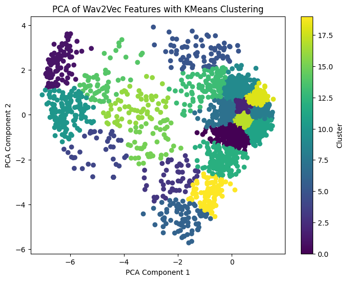

```python
import numpy as np
from sklearn.model_selection import train_test_split
from sklearn.ensemble import RandomForestClassifier
from sklearn.metrics import classification_report
from sklearn.decomposition import PCA
from sklearn.cluster import KMeans
import matplotlib.pyplot as plt


data = np.load('dataset.npz')
features = data['features']
labels = data['labels']


features_flattened = features.reshape(features.shape[0], -1)

X_train, X_test, y_train, y_test = train_test_split(
    features_flattened, labels, test_size=0.2, stratify=labels
)


classifier = RandomForestClassifier()
classifier.fit(X_train, y_train)
y_pred = classifier.predict(X_test)

print("Classification Report:")
print(classification_report(y_test, y_pred))

pca = PCA(n_components=2)
pca_result = pca.fit_transform(features_flattened)

num_speakers = len(np.unique(labels))  # Number of unique speaker labels
kmeans = KMeans(n_clusters=num_speakers)
clusters = kmeans.fit_predict(pca_result)

plt.figure(figsize=(8, 6))
plt.scatter(pca_result[:, 0], pca_result[:, 1], c=clusters, cmap='viridis')
plt.title('PCA of Wav2Vec Features with KMeans Clustering')
plt.xlabel('PCA Component 1')
plt.ylabel('PCA Component 2')
plt.colorbar(label='Cluster')
plt.show()
```

### I performed the PCA with 2 most effective features and then applied clustering algorithm with 20 classes since I have 10 male and 10 female sample in my dataset

```python
data = np.load('dataset.npz')
features = data['features']  # Shape: (5545, 1, 768)
labels = data['labels']      # Shape: (5545,)

features.shape
labels.shape
```

```
(5545,)
```

# Building neural networks

```
Classification Report:
{'1272': {'precision': 0.8793103448275862, 'recall': 0.9272727272727272, 'f1-score': 0.9026548672566371, 'support': 55.0}, '1462': {'precision': 0.6666666666666666, 'recall': 0.8666666666666667, 'f1-score': 0.7536231884057971, 'support': 60.0}, '1673': {'precision': 0.9318181818181818, 'recall': 0.7…
Precision: 0.85, Recall: 0.84, F1 Score: 0.84, Accuracy: 0.84
```

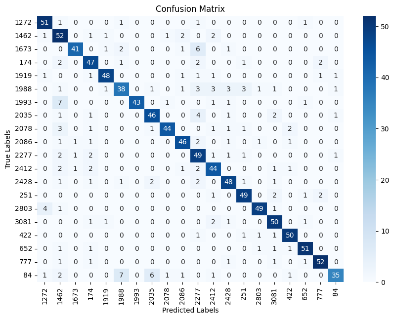

```python
import numpy as np
import torch
import torch.nn as nn
import torch.optim as optim
from torch.utils.data import DataLoader, TensorDataset
from sklearn.model_selection import train_test_split
from sklearn.metrics import classification_report, confusion_matrix, accuracy_score
from sklearn.preprocessing import LabelEncoder
import seaborn as sns
import matplotlib.pyplot as plt


data = np.load('dataset.npz')
features = data['features']
labels = data['labels']

# Reshape features to (5545, 768) to remove the extra dimension
features = features.reshape(features.shape[0], -1)

# Map non-sequential labels to sequential integers
label_encoder = LabelEncoder()
labels_encoded = label_encoder.fit_transform(labels)

X = torch.tensor(features, dtype=torch.float32)
y = torch.tensor(labels_encoded, dtype=torch.long)

# Split the dataset
X_train, X_test, y_train, y_test = train_test_split(X, y, test_size=0.2, stratify=y)

# for batching
batch_size = 32
train_dataset = TensorDataset(X_train, y_train)
test_dataset = TensorDataset(X_test, y_test)
train_loader = DataLoader(train_dataset, batch_size=batch_size, shuffle=True)
test_loader = DataLoader(test_dataset, batch_size=batch_size, shuffle=False)


class BasicNN(nn.Module):
    def __init__(self, num_classes):
        super(BasicNN, self).__init__()
        self.fc1 = nn.Linear(768, 128)  # Input
        self.fc2 = nn.Linear(128, 64)    # Hidden
        self.fc3 = nn.Linear(64, num_classes)  # Output
        self.relu = nn.ReLU()

    def forward(self, x):
        x = self.relu(self.fc1(x))  # First hidden
        x = self.relu(self.fc2(x))  # Second hidden
        x = self.fc3(x)              # Output
        return x

num_classes = len(np.unique(labels_encoded))
model = BasicNN(num_classes)

criterion = nn.CrossEntropyLoss()
optimizer = optim.Adam(model.parameters(), lr=0.001)


num_epochs = 10
for epoch in range(num_epochs):
    model.train()
    running_loss = 0.0
    for inputs, labels in train_loader:
        optimizer.zero_grad()
        outputs = model(inputs)
        loss = criterion(outputs, labels)
        loss.backward()
        optimizer.step()
        running_loss += loss.item()

    print(f"Epoch {epoch+1}/{num_epochs}, Loss: {running_loss / len(train_loader)}")


model.eval()
y_true = []
y_pred = []
with torch.no_grad():
    for inputs, labels in test_loader:
        outputs = model(inputs)
        _, predicted = torch.max(outputs, 1)
        y_true.extend(labels.numpy())
        y_pred.extend(predicted.numpy())

# Decode the predicted labels back to the original labels
y_true = label_encoder.inverse_transform(y_true)
y_pred = label_encoder.inverse_transform(y_pred)


report = classification_report(y_true, y_pred, output_dict=True)
print("Classification Report:")
print(report)

precision = report['weighted avg']['precision']
recall = report['weighted avg']['recall']
f1 = report['weighted avg']['f1-score']
accuracy = accuracy_score(y_true, y_pred)

print(f"Precision: {precision:.2f}, Recall: {recall:.2f}, F1 Score: {f1:.2f}, Accuracy: {accuracy:.2f}")

cm = confusion_matrix(y_true, y_pred)
plt.figure(figsize=(10, 7))
sns.heatmap(cm, annot=True, fmt='d', cmap='Blues', xticklabels=label_encoder.classes_, yticklabels=label_encoder.classes_)
plt.title('Confusion Matrix')
plt.xlabel('Predicted Labels')
plt.ylabel('True Labels')
plt.show()
```

# Building 1D CNN

```
Classification Report:
{'1272': {'precision': 0.8679245283018868, 'recall': 0.8363636363636363, 'f1-score': 0.8518518518518519, 'support': 55.0}, '1462': {'precision': 0.717948717948718, 'recall': 0.9333333333333333, 'f1-score': 0.8115942028985508, 'support': 60.0}, '1673': {'precision': 1.0, 'recall': 0.9615384615384616,…
Precision: 0.90, Recall: 0.88, F1 Score: 0.89, Accuracy: 0.88
```

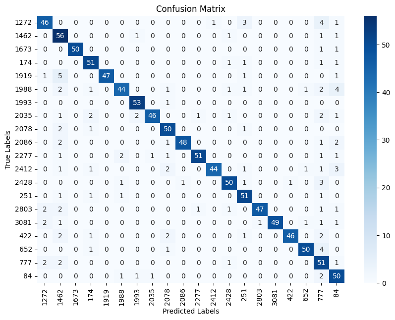

```python
import numpy as np
import torch
import torch.nn as nn
import torch.optim as optim
from torch.utils.data import DataLoader, TensorDataset
from sklearn.model_selection import train_test_split
from sklearn.metrics import classification_report, confusion_matrix, accuracy_score
from sklearn.preprocessing import LabelEncoder
import seaborn as sns
import matplotlib.pyplot as plt


data = np.load('dataset.npz')
features = data['features']
labels = data['labels']

features = features.reshape(features.shape[0], -1)

label_encoder = LabelEncoder()
labels_encoded = label_encoder.fit_transform(labels)

X = torch.tensor(features, dtype=torch.float32)
y = torch.tensor(labels_encoded, dtype=torch.long)

X_train, X_test, y_train, y_test = train_test_split(X, y, test_size=0.2, stratify=y)


X_train = X_train.unsqueeze(1)
X_test = X_test.unsqueeze(1)

batch_size = 32
train_dataset = TensorDataset(X_train, y_train)
test_dataset = TensorDataset(X_test, y_test)
train_loader = DataLoader(train_dataset, batch_size=batch_size, shuffle=True)
test_loader = DataLoader(test_dataset, batch_size=batch_size, shuffle=False)

# Define the 1D CNN model
class CNN1D(nn.Module):
    def __init__(self, num_classes):
        super(CNN1D, self).__init__()
        self.conv1 = nn.Conv1d(in_channels=1, out_channels=32, kernel_size=3, padding=1)
        self.conv2 = nn.Conv1d(in_channels=32, out_channels=64, kernel_size=3, padding=1)
        self.pool = nn.MaxPool1d(kernel_size=2)  # Max Pooling Layer (downsampling by a factor of 2)
        self.fc1 = nn.Linear(64 * (768 // 2 // 2), 128)
        self.fc2 = nn.Linear(128, num_classes)
        self.relu = nn.ReLU()

    def forward(self, x):
        x = self.pool(self.relu(self.conv1(x)))
        x = self.pool(self.relu(self.conv2(x)))
        x = x.view(x.size(0), -1)
        x = self.relu(self.fc1(x))
        x = self.fc2(x)
        return x

num_classes = len(np.unique(labels_encoded))
model = CNN1D(num_classes)

criterion = nn.CrossEntropyLoss()
optimizer = optim.Adam(model.parameters(), lr=0.001)

num_epochs = 10
for epoch in range(num_epochs):
    model.train()
    running_loss = 0.0
    for inputs, labels in train_loader:
        optimizer.zero_grad()
        outputs = model(inputs)
        loss = criterion(outputs, labels)
        loss.backward()
        optimizer.step()
        running_loss += loss.item()

    print(f"Epoch {epoch+1}/{num_epochs}, Loss: {running_loss / len(train_loader)}")

model.eval()
y_true = []
y_pred = []
with torch.no_grad():
    for inputs, labels in test_loader:
        outputs = model(inputs)
        _, predicted = torch.max(outputs, 1)
        y_true.extend(labels.numpy())
        y_pred.extend(predicted.numpy())

y_true = label_encoder.inverse_transform(y_true)
y_pred = label_encoder.inverse_transform(y_pred)

report = classification_report(y_true, y_pred, output_dict=True)
print("Classification Report:")
print(report)

precision = report['weighted avg']['precision']
recall = report['weighted avg']['recall']
f1 = report['weighted avg']['f1-score']
accuracy = accuracy_score(y_true, y_pred)

print(f"Precision: {precision:.2f}, Recall: {recall:.2f}, F1 Score: {f1:.2f}, Accuracy: {accuracy:.2f}")

cm = confusion_matrix(y_true, y_pred)
plt.figure(figsize=(10, 7))
sns.heatmap(cm, annot=True, fmt='d', cmap='Blues', xticklabels=label_encoder.classes_, yticklabels=label_encoder.classes_)
plt.title('Confusion Matrix')
plt.xlabel('Predicted Labels')
plt.ylabel('True Labels')
plt.show()
```

### 1D CNN performed really good with good f1 score and accuracy.

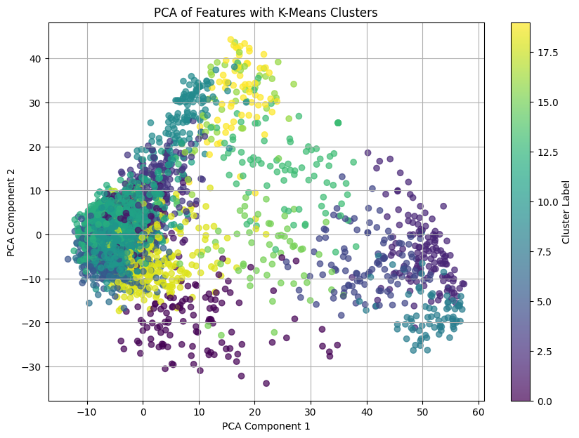

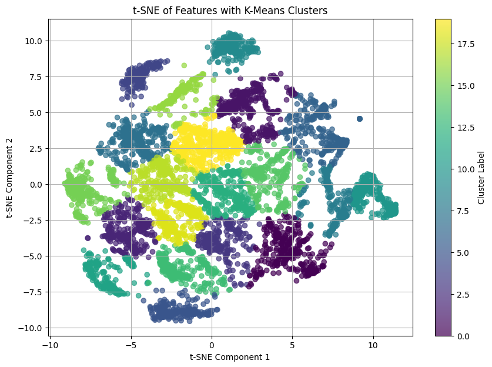

```
Silhouette Score for K-Means: 0.045
```

```python
import numpy as np
import matplotlib.pyplot as plt
import seaborn as sns
from sklearn.decomposition import PCA
from sklearn.manifold import TSNE
from sklearn.cluster import KMeans
from sklearn.preprocessing import StandardScaler
from sklearn.metrics import silhouette_score

data = np.load('dataset.npz')
features = data['features']

features = features.reshape(features.shape[0], -1)

# Standardize the features
scaler = StandardScaler()
features_scaled = scaler.fit_transform(features)

# Dimensionality Reduction using PCA
pca = PCA(n_components=2)
features_pca = pca.fit_transform(features_scaled)

# Clustering using K-Means
num_clusters = 20  # Adjust this based on your data
kmeans = KMeans(n_clusters=num_clusters, random_state=42)
clusters = kmeans.fit_predict(features_scaled)

# Visualize PCA Results with Clusters
plt.figure(figsize=(10, 7))
plt.scatter(features_pca[:, 0], features_pca[:, 1], c=clusters, cmap='viridis', marker='o', alpha=0.7)
plt.title('PCA of Features with K-Means Clusters')
plt.xlabel('PCA Component 1')
plt.ylabel('PCA Component 2')
plt.colorbar(label='Cluster Label')
plt.grid(True)
plt.show()

# Dimensionality Reduction using t-SNE for better visualization
tsne = TSNE(n_components=2, perplexity=30, n_iter=300)
features_tsne = tsne.fit_transform(features_scaled)

# Clustering using K-Means on t-SNE results
clusters_tsne = kmeans.fit_predict(features_tsne)

# Visualize t-SNE Results with Clusters
plt.figure(figsize=(10, 7))
plt.scatter(features_tsne[:, 0], features_tsne[:, 1], c=clusters_tsne, cmap='viridis', marker='o', alpha=0.7)
plt.title('t-SNE of Features with K-Means Clusters')
plt.xlabel('t-SNE Component 1')
plt.ylabel('t-SNE Component 2')
plt.colorbar(label='Cluster Label')
plt.grid(True)
plt.show()

# Evaluate clustering quality using Silhouette Score
silhouette_avg = silhouette_score(features_scaled, clusters)
print(f'Silhouette Score for K-Means: {silhouette_avg:.3f}')
```

### Silhouette score is really low which means the member of the classes are not that different from other classes. Meaning the classes are really similar and by looking at the PCA we can say that most effective 2 variables are not that useful by themselves, the data seems intermingled in both of the figures especially in PCA.